# Activity 2: Statistical Maps II

# Activity 2: Statistical Maps II

Remember, you can download the source file for this activity from [here](https://github.com/paezha/Spatial-Statistics-Course).

## Housekeeping Questions

Answer the following questions:

1. How many examinations are there in this course?
2. What is the date of the first examination?
3. Where is the office of your instructor?

## Learning objectives

In this activity you will:

1. Learn about patterns and processes, including random patterns.
2. Understand the general approach to retrieve a process from a pattern.
3. Discuss the importance of discriminating random patterns.

## Suggested reading

O’Sullivan D and Unwin D (2010) Geographic Information Analysis, 2nd Edition, Chapters 1-3. John Wiley & Sons: New Jersey.

## Preliminaries

For this activity you will need the following:

- An R markdown notebook version of this document (the source file).
- A package called `geog4ga3`.

It is good practice to clear the working space to make sure that you do not have extraneous items there when you begin your work. The command in R to clear the workspace is `rm` (for “remove”), followed by a list of items to be removed. To clear the workspace from *all* objects, do the following:

```r
rm(list = ls())
```

Note that `ls()` lists all objects currently on the worspace.

Load the libraries you will use in this activity:

```r
library(tidyverse)
library(geog4ga3)
```

Now that your workspace is clear, you can proceed to invoke the datasets required for this activity:

```r
data("missing_df")
data("PointPattern1")
data("PointPattern2")
data("PointPattern3")
```

The datasets include the following dataframe which will be used in the first part of the activity:

- `missing_df`

This dataframe includes $n = 65$ observations (Note: text between $ characters is mathematical notation in LaTeX). These observations are geocoded using a false origin and coordinates normalized to the unit-square (the extent of their values is between zero and one). The coordinates are `x` and `y`. In addition, there are three variables associated with the locations (VAR1, VAR2, VAR3). The variables are generic. Feel free to think of them as if they were housing prices or concentrations in ppb of some contaminant. Finally, a factor variable states whether the variables were measured for a location: if the status is “FALSE”, the values of the variables are missing.

The following dataframes will be used in the second part of the activity:

- `PointPattern1`
- `PointPattern2`
- `PointPattern3`

The dataframes `PointPattern*` are locations of some generic events. The coordinates `x` and `y` are also based on a false origin and are normalized to the unit-square. Feel free to think of these events as cases of flu, the location of trees of a certain species, or the location of fires.

## Activity

1. Create thematic maps for variables VAR1 through VAR3 in the dataframe `missing_df`.

```r
ggplot(missing_df) +
  geom_sf(aes(fill = cut_number(missing_df$VAR1, 5)), color = "black", alpha = 1, size = .3) +
  scale_fill_brewer(palette = "Reds") +
  coord_sf() +
  labs(fill = "Variable")
```

[output not shown]

```
Error in FUN(X[[i]], ...) : object 'geometry' not found
```

2. Suppose that you were tasked with estimating the value of a variable for the locations where those were not measured. For instance, you could be a realtor, and you need to assess the value of a property, and the only information available is the published values of other properties in the region. As an alternative, you could be an environmental scientist, and you need to estimate what the concentration of a contaminant at a site, based on previous measurements at other sites in the region.

Propose one or more ways to guess those missing values, and explain your reasoning. The approach does not need to be the same for all variables!

3. Plot all three point patterns.

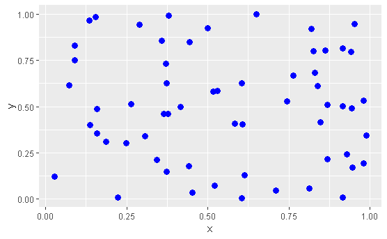

```r
ggplot(PointPattern1) +
  geom_point(data = PointPattern1, aes(x=x, y=y), colour = 'blue', size =3)
```

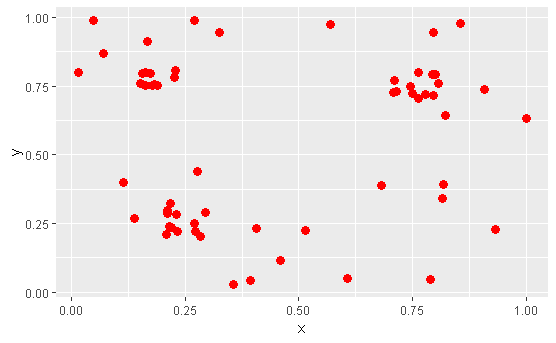

```r
ggplot(PointPattern2) +
  geom_point(data = PointPattern2, aes(x=x, y=y), colour = 'red', size =3)
```

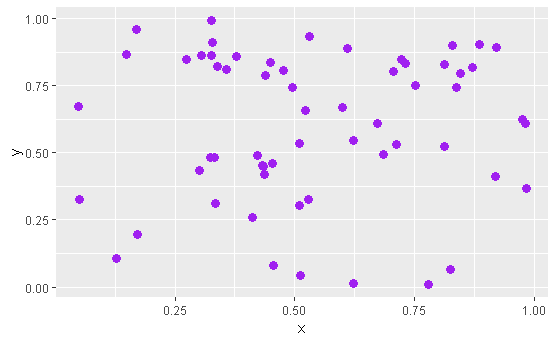

```r
ggplot(PointPattern3) +
  geom_point(data = PointPattern3, aes(x=x, y=y), colour = 'purple', size =3)
```

4. Imagine that you are a public health official and you need to plan services to the public. If you were asked to guess where the next event would emerge, where would be your guess in each map? Explain your answer.